# PHOIBLE frequently asked questions

Steven Moran & Daniel McCloy

# Introduction

This FAQ answers questions regarding the editorial principles and design decisions that went into the creation of PHOIBLE. We appreciate and welcome feedback regarding these FAQs via [our issue tracker](https://github.com/phoible/dev/issues) or by contacting the editors directly.

When relevant, we provide [R](https://www.r-project.org/) code snippets to elucidate the questions raised in this FAQ. To run these code snippets requires the following [R packages](https://cran.r-project.org/web/packages/available_packages_by_name.html):

```r
library(readr)
library(stringr)
library(dplyr)
library(knitr)
library(ggplot2)
```

This document was rendered with R version 3.6.2 (2019-12-12) and package versions dplyr: 1.0.5, readr: 1.3.1, stringr: 1.4.0, knitr: 1.31, ggplot2: 3.2.1.

## How do I get the data?

You can get the most recent “official” release from our [download page](https://phoible.org/download), get the most current version (with bugfixes or new additions since last release) from [GitHub](https://github.com/phoible/dev/blob/master/data/phoible.csv?raw=true), or use the following code snippet to download the most current version from GitHub directly within `R`:

```r
url_ <- "https://github.com/phoible/dev/blob/master/data/phoible.csv?raw=true"
col_types <- cols(InventoryID='i', Marginal='l', .default='c')
phoible <- read_csv(url(url_), col_types=col_types)
```

# Inventories, language codes, doculects, and sources

## How are PHOIBLE inventories created?

For the most part, every phonological inventory in PHOIBLE is based on one-and-only-one language description (usually a research article, book chapter, dissertation, or descriptive grammar). The technical term for this in comparative linguistics is “doculect” (from “documented lect”), in which lect means a specific form of a language or dialect, i.e. an instance of documentation of an instance of linguistic behavior at a particular time and place (Cysouw & Good, 2013). A brief explanation and some history of why linguists use the term “doculect”, which has gained broad acceptance in light of the issues of language identification and the use of “language codes”, is given in [this blog post](https://dlc.hypotheses.org/623) by Michael Cysouw.

Contributors to PHOIBLE start with a doculect, extract the contrastive phonemes and allophones, and (if necessary) adapt the authors’ choice of symbols to align with PHOIBLE’s [symbol guidelines](http://phoible.github.io/conventions/). If the authors have not provided ISO 639-3 and Glottolog codes, these are determined before adding the inventory to PHOIBLE. Each inventory is then given a unique numeric ID. Doculects are tracked in PHOIBLE using BibTeX keys.

## Why do some phonological inventories combine more than one doculect?

An exception to the “one doculect per inventory” rule arises for inventories that were originally part of a curated phonological database such as UPSID (Maddieson, 1984; Maddieson & Precoda, 1990) or SPA (Crothers, Lorentz, Sherman, & Vihman, 1979). In those collections, inventories were often based on multiple descriptions of linguistic behavior, written by different linguists; those descriptions were believed to be describing the same language, and disagreements between the descriptions were adjudicated by the experts who compiled the collection.

We can quickly see how many of PHOIBLE’s inventories are based on multiple doculects by looking at the mapping table between PHOIBLE inventory IDs and BibTeX keys:

```r
url_ <- "https://github.com/phoible/dev/blob/master/mappings/InventoryID-Bibtex.csv?raw=true"
id_to_bibtex_mapping <- read_csv(url(url_), col_types=cols(InventoryID='i',
                                                           .default='c'))

id_to_bibtex_mapping %>%
    group_by(InventoryID) %>%
    tally(name="Number of doculects consulted") %>%
    group_by(`Number of doculects consulted`) %>%
    count(name="Number of inventories") %>%
    kable()
```

| Number of doculects consulted | Number of inventories |
| --- | --- |
| 1 | 2435 |
| 2 | 442 |
| 3 | 93 |
| 4 | 29 |
| 5 | 10 |
| 6 | 7 |
| 7 | 2 |
| 9 | 1 |
| 11 | 1 |

Clearly, the majority of inventories in PHOIBLE represent a phonological description from a single doculect. But it seems strange that a single phonological inventory in PHOIBLE could be based on 11 different doculects. Let’s examine it:

```r
id_to_bibtex_mapping %>%
    group_by(InventoryID) %>%
    tally(name="Number of doculects consulted") %>%
    filter(`Number of doculects consulted` == 11) %>%
    pull(InventoryID) ->
    this_inventory_id

phoible %>%
    filter(InventoryID == this_inventory_id) %>%
    distinct(Source, LanguageName, Glottocode, ISO6393) %>%
    kable()
```

| Glottocode | ISO6393 | LanguageName | Source |
| --- | --- | --- | --- |
| haus1257 | hau | HAUSA | upsid |

As we can see, this inventory represents a description of [Hausa](https://glottolog.org/resource/languoid/id/haus1257) and was added to PHOIBLE from the UPSID database (Maddieson, 1984; Maddieson & Precoda, 1990). To understand why this UPSID entry consulted 11 different sources, consider first that Hausa is typologically interesting (e.g., it has both ejective and implosive phonation mechanisms) and has tens of millions of speakers, making it relatively well-studied (the [Glottolog](https://glottolog.org/) reference catalog has [more than 1400 references](https://glottolog.org/resource/languoid/id/haus1257) related to Hausa).

Second, note that Maddieson’s work on UPSID involved “typologizing” phonological inventories from different doculects, so that they were comparable across all entries in his database (cf. Hyman, 2008). Maddieson’s work was groundbreaking at the time because he was the first typologist to generate a stratified language sample aimed at being genealogically balanced, i.e. for each language family he chose one representative language. This allowed Maddieson to make statements about the cross-linguistic distribution of contrastive speech sounds with some level of statistical confidence. In fact, much about what we know about the distribution of the sounds of the world’s languages is due to Maddieson’s original language sample and his meticulous curation of the data.

## Where do the language codes in PHOIBLE come from?

Every phonological inventory in PHOIBLE has a unique numeric inventory ID. Since most PHOIBLE inventories (aside from some UPSID or SPA ones, as mentioned above) are based on a single document, it is fairly straightforward to link each PHOIBLE inventory to [the Glottolog](https://glottolog.org/), which provides links between linguistic description documents and unique identifiers for dialects, languages, and groupings of dialects and languages at various levels (the preferred term for any of these levels of specificity / grouping is “languoid”; see Cysouw & Good, 2013). Thus in PHOIBLE each inventory typically corresponds to a single languoid, and in most cases that languoid is a “leaf node” in the Glottolog tree, i.e., it represents a particular dialect known to be used at a particular place and time (rather than a group of dialects, a language, or a language family). However, in the few cases where multiple document sources were consulted for an inventory, it may not be possible to link that inventory to a unique Glottolog leaf node. In such cases, the inventory in PHOIBLE is linked to the lowest possible Glottolog node that dominates the leaf nodes of each source document.

For example, inventory 298 describes the Dan language, and was ingested from UPSID and ultimately based on a single journal article. At the time UPSID was compiled, Dan and Kla-Dan were considered a single language (isocode `daf`) but in 2013 a proposal was accepted to assign them separate isocodes (`dnj` and `lda`, respectively). Since it is unknown whether the consultants for the doculect were speakers of what we would now call “Dan” or “Kla-Dan”, the inventory is labeled with the old isocode `daf` and linked to the corresponding non-leaf node in the glottolog (`dann1241`).

In addition to providing Glottolog languoid codes (“glottocodes”) for each inventory, PHOIBLE also includes [ISO 639-3](https://en.wikipedia.org/wiki/ISO_639-3) language codes (“isocodes”) for each inventory. The link between glottocodes and isocodes is maintained and provided by Glottolog. This situation can result in two possible problems:

- When there are [updates to ISO 639-3](https://iso639-3.sil.org/code_changes/submitting_change_requests), the Glottolog may not update its mapping immediately, so the two can get out of sync temporarily. Such problems are typically resolved with new version releases of Glottolog.
- In some cases, the editors of the Glottolog do not agree with the language classification choices of ISO 639-3 (see again the above-mentioned [blog post by Cysouw](https://dlc.hypotheses.org/623)). This disagreement results in cases where PHOIBLE must choose whether to accept the official ISO 639-3 code assignment, or use the isocode that the Glottolog associates with the glottocode for that inventory. In such cases, PHOIBLE policy is to report the ISO 639-3 version of the isocode. Consequently, there are a few languoids for which PHOIBLE and the Glottolog will report different isocodes for the same glottocode. If this is a problem for your analysis, you can always download a glottocode-isocode mapping from the Glottolog and merge it into the PHOIBLE dataset before performing your isocode-based analyses.

## Missing isocodes

There are cases of languages reported in the Glottolog for which there exists no isocode. For example, the Vach-Vasjugan variety of [Khanty](https://en.wikipedia.org/wiki/Khanty_language) is a Uralic language classified in the Glottolog as vach1239. However, [SIL](https://www.sil.org/) only assigns an isocode for one variety of Northern Khanty (isocode `kca`, glottocode `khan1273`), and because SIL is the Registration Authority of [ISO 639-3](https://iso639-3.sil.org/), Vach-Vasjugan Khanty has not been assigned its own isocode distinct from Northern Khanty.

When no isocode exists for a particular phonological inventory in PHOIBLE, as in the Vach-Vasjugan example above, PHOIBLE follows the recommended practice of using the isocode `mis` (“missing”) to denote that the language is not included in the ISO 639-3 standard. In PHOIBLE these are these inventories with missing isocodes:

```r
phoible %>%
    filter(ISO6393 == "mis") %>%
    distinct(InventoryID, LanguageName, ISO6393, Glottocode) %>%
    kable()
```

| InventoryID | Glottocode | ISO6393 | LanguageName |
| --- | --- | --- | --- |
| 2143 | pisa1245 | mis | Pisamira |
| 2352 | lizu1234 | mis | Lizu |
| 2388 | east2773 | mis | Dolakha Newar |
| 2420 | zhon1235 | mis | Zhongu Tibetan |
| 2434 | vach1239 | mis | Eastern Khanty |
| 2450 | fore1274 | mis | Forest Nenets |
| 2691 | mink1237 | mis | Minkin |
| 2714 | guwa1244 | mis | Guwar |
| 2729 | NA | mis | Djindewal |
| 2748 | mith1236 | mis | Mithaka |
| 2773 | cola1237 | mis | Kolakngat |
| 2778 | yari1243 | mis | Yari-Yari |
| 2782 | west2443 | mis | East Djadjawurung |
| 2783 | djad1246 | mis | Jardwadjali |
| 2792 | kera1256 | mis | Keramin |
| 2793 | lowe1402 | mis | Ngayawang |
| 2794 | ngin1247 | mis | Ngintait |
| 2818 | gudj1237 | mis | Gudjal |
| 2882 | kawa1290 | mis | Ogh Awarrangg |
| 2883 | kawa1290 | mis | Ogh Unyjan |
| 2907 | wala1263 | mis | Walangama |
| 2911 | tyan1235 | mis | Thaynakwithi |
| 2913 | luth1234 | mis | Luthigh |
| 2914 | mbiy1238 | mis | Mbiywom |
| 2916 | ngko1236 | mis | Ngkoth |
| 2920 | yadh1237 | mis | Yadhaykenu |
| 2946 | bula1255 | mis | Bularnu |
| 2956 | yulp1239 | mis | Yulparija |
| 2988 | west2443 | mis | West Djadjawurung |
| 2999 | sout2770 | mis | Ngunawal |

Many of these inventories come from [Erich Round’s](https://languages-cultures.uq.edu.au/profile/1160/erich-round) [contribution of Australian phonemic inventories](https://zenodo.org/record/3464333#.XyK5qxMzY3E) to PHOIBLE. Unfortunately, some of these languages are extinct and have no representation in the [Ethnologue](https://www.ethnologue.com/), and hence, no code assigned in ISO 639-3.

For users, it is important to note that multiple phonological inventories in PHOIBLE may have the same isocode (e.g. “mis”) or the same glottocode (e.g., in cases of two different descriptions of the same lect). In essence, this means that any programmatic code that groups by isocode or glottocode risks combining inventories from different doculects into a single apparent inventory. This could lead to incorrect results (e.g., if the goal is to count the number of phonemes). Therefore, **most analyses of inventory properties should be done on the level of inventory IDs** rather than isocodes or glottocodes. See also the section on filtering and sampling below.

## Why do some languages have multiple entries in PHOIBLE?

It is not uncommon that phonological descriptions of a particular language’s speech sounds have different sets of contrastive phonemes when analyzed by different linguists (or sometimes even by the same linguist throughout their career). For example, [Kabardian](https://en.wikipedia.org/wiki/Kabardian_language) is represented in PHOIBLE by [five distinct inventories](https://phoible.org/languages/kaba1278).

```r
phoible %>%
    filter(ISO6393 == "kbd") %>%
    group_by(InventoryID) %>%
    summarise(`Number of phonemes`=n(),
              Phonemes=str_c(Phoneme, collapse=" "),
              .groups="drop") %>%
    kable()
```

| InventoryID | Number of phonemes | Phonemes |
| --- | --- | --- |
| 4 | 56 | b d̻ d̻z̻ f fʼ j kʷʰ kʷʼ k̟ʲʰ k̟ʲʼ m n̻ pʰ pʼ qχ qχʷ qχʷʼ qχʼ r s̻ t̻s̻ t̻s̻ʼ t̻ʰ t̻ʼ v w xʷ x̟ʲ z̻ ç̟ ħ ɡʷ ɡ̟ʲ ɣ̟ʲ ɦ ɬʲ ɬʲʼ ɮʲ ʁ ʁʷ ʃ ʃʼ ʒ ʔ ʔʷ ʕ ʝ̟ χ χʷ a̟ː e̞ː iː o̞ː uː ɜ ɨ |
| 391 | 56 | b d̪ d̪z̪ f fʼ j kʲʰ kʲʼ kʷʰ kʷʼ m n̪ pʰ pʼ qʷʼ qʼ qχ qχʷ r s̪ t̪s̪ t̪s̪ʼ t̪ʰ t̪ʼ v w xʲ xʷ z̪ ħ ɡʲ ɡʷ ɣʲ ɦ ɬ̪ʲ ɬ̪ʲʼ ɮ̪ʲ ʁ ʁʷ ʃ ʃʼ ʃ͇ ʒ ʒ͇ ʔ ʔʷ ʕ χ χʷ a̟ː e̞ː iː o̞ː uː ɜ ɨ |
| 2310 | 55 | b d dz d̠ʒ f fʼ j kʷ kʷʼ m n p pʼ q qʷ qʷʼ qʼ r s t ts tsʼ tʼ t̠ʃ t̠ʃʼ v w x xʷ z ħ ɡʷ ɣ ɬ ɬʼ ɮ ʁ ʁʷ ʃ ʆ ʆʼ ʒ ʓ ʔ ʔʷ χ χʷ ä e̞ː iː o̞ o̞ː uː ɑː ə |
| 2401 | 63 | b d dz dʑ f fʼ j kʷ kʷʼ kʼ l m n p pʼ q qʷ qʷʼ qʼ r s t ts tsʷʼ tsʼ tɕ tɕʼ tʷʼ tʼ t̠ʃ t̠ʃʼ v w x xʷ z zʷ ħ ɕ ɡʷ ɣ ɬ ɬʼ ʁ ʁʷ ʃ ʆ ʆʼ ʑ ʒ ʓ ʔ ʔʷ χ χʷ ä e̞ː iː o̞ o̞ː uː ɑː ə |
| 2610 | 51 | b d dz f fʼ h j kʲʼ kʷʰ kʷʼ l m n pʰ pʼ qʰ qʷʰ qʷʼ qʼ s ts tsʼ tʰ tʼ w xʷ z ç ħ ɡʲ ɡʷ ɬ ɬʼ ɾ ʁ ʁʷ ʃ ʃʼ ʒ ʔ ʔʷ ʝ χ χʷ äː eː iː oː uː ɐ ə |

The differences among them can be due to a variety of reasons, but the main reason is that these phonological descriptions represent different doculects (i.e., different instances of linguistic behavior at different places, times, or with different speakers). This should probably not surprise most linguists, since it has long been known that phoneme analysis is a non-deterministic process (Chao, 1934; Hockett, 1963). See Moran (2012, ch. 2.3.3) for a general discussion, and Hyman (2008, p. 99) for a detailed discussion of Kabardian in particular.

In light of the above discussion, it should come as no surprise that PHOIBLE can contain multiple inventories for “the same” languoid, depending on what kind of languoid you’re interested in. All it takes is the existence of two or more descriptive documents associated with the same group of speakers, where “group of speakers” is ultimately determined by your desired level of granularity. To give a concrete example, one researcher may be interested in comparing lects at the “language” level, and so might wish to treat all inventories of “English” as duplicates for the purposes of her analysis (regardless of any differences in regional dialect or sociolect represented in the original doculects and encoded in the phonological inventory). That researcher might *filter* or *sample* PHOIBLE’s inventories to include only one inventory for each isocode (how she chooses to implement that filter is a separate question; see “How can I filter or sample inventories?” for examples). Other researchers may not care about “duplicates” in that sense, and may choose to include all inventories in their analysis (or, they may filter the dataset to include only inventories with a particular feature of interest such as breathy-voiced vowels).

Below is a summary of the number of isocodes that are represented by multiple inventories in PHOIBLE:

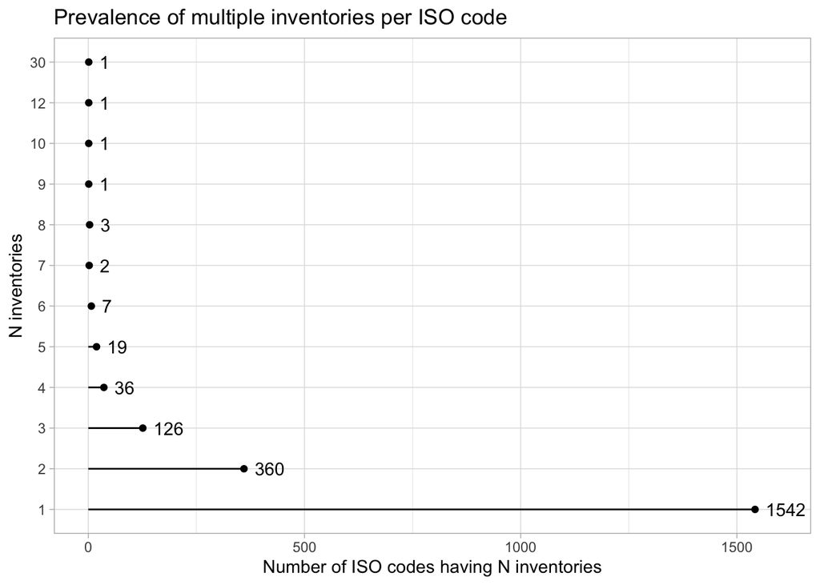

```r
offset <- 25
phoible %>%
    group_by(ISO6393) %>%
    summarise(y=n_distinct(InventoryID), .groups="drop") %>%
    count(y) ->
    counts
counts %>%
    ggplot(aes(y=as.factor(y), x=n)) +
    geom_point() +
    geom_text(aes(x=n+offset, label=n), hjust=0) +
    geom_segment(aes(xend=0, yend=as.factor(y))) +
    xlim(NA, max(counts$n) + 2*offset) +
    theme_light() +
    labs(title="Prevalence of multiple inventories per ISO code",
         x="Number of ISO codes having N inventories",
         y="N inventories")
```

So most ISO 639-3 codes have only 1 inventory (the long, bottom line).

Here is the same representation, for glottocodes instead of isocodes:

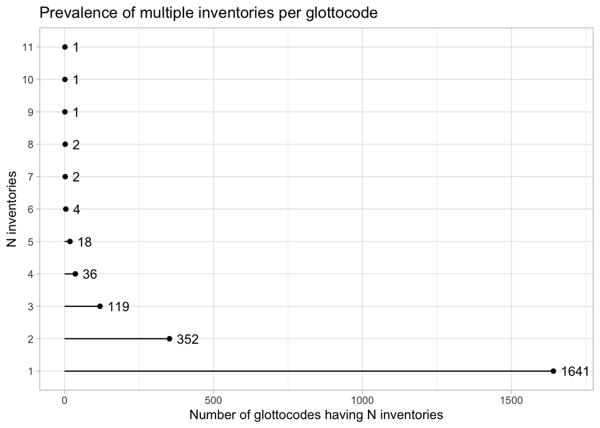

```r
offset <- 25
phoible %>%
    group_by(Glottocode) %>%
    summarise(y=n_distinct(InventoryID), .groups="drop") %>%
    count(y) ->
    counts
counts %>%
    ggplot(aes(y=as.factor(y), x=n)) +
    geom_point() +
    geom_text(aes(x=n+offset, label=n), hjust=0) +
    geom_segment(aes(xend=0, yend=as.factor(y))) +
    xlim(NA, max(counts$n) + 2*offset) +
    theme_light() +
    labs(title="Prevalence of multiple inventories per glottocode",
         x="Number of glottocodes having N inventories",
         y="N inventories")
```

Again, most glottocodes are represented by just one or two inventories in PHOIBLE. Let’s see the few glottocodes that have the most inventories:

```r
phoible %>%
    group_by(Glottocode) %>%
    summarise(Names=str_c(unique(LanguageName), collapse=", "),
              `Number of inventories`=n_distinct(InventoryID),
              .groups="drop") %>%
    arrange(desc(`Number of inventories`)) %>%
    filter(`Number of inventories` > 5) %>%
    kable()
```

| Glottocode | Names | Number of inventories |
| --- | --- | --- |
| osse1243 | Ossetian, Iron Ossetic | 11 |
| biri1256 | Barna, Biri, Garingbal, Miyan, Wiri, Yambina, Yangga, Yilba, Yuwi, Wangan | 10 |
| stan1293 | English, English (American), American English, English (Australian), English (British), English (New Zealand) | 9 |
| dutc1256 | Dutch | 8 |
| kham1282 | Rgyalthang Tibetan, Brag-g.yab Tibetan, Nangchenpa Tibetan, Soghpo Tibetan, Kami Tibetan, Sangdam Tibetan, Dongwang Tibetan, Kham Tibetan | 8 |
| basq1248 | Basque, BASQUE | 7 |
| east2328 | Cheremis, MARI, Meadow Mari, Eastern Mari | 7 |
| gwan1268 | Gwandara (Karshi), Gwandara (Cancara), Gwandara (Toni), Gwandara (Gitata), Gwandara (Koro), Gwandara (Nimbia) | 6 |
| khan1273 | Ostyak, KHANTY, Eastern Khanty, Northern Khanty | 6 |
| lazz1240 | Laz | 6 |
| lith1251 | Lithuanian, LITHUANIAN | 6 |

## Why are multiple inventories sometimes linked to the same document?

Occasionally, a single document may provide information about multiple phonological inventories. For example, a dissertation that describes and compares three related dialects or languages spoken in a particular region. In that case, three phonological inventories in PHOIBLE corresponding to three doculects might all be linked to the same document, but each inventory is still linked to only one document (it just happens to be *the same document* for those three inventories). One example is Terrill (1998), a grammar of [Biri](https://en.wikipedia.org/wiki/Biri_language), which contains a chapter describing its dialects, [many of which appear in PHOIBLE](https://phoible.org/languages/biri1256).

## What are the different “sources” in PHOIBLE?

PHOIBLE contains inventories from various contributors. These contributions are grouped into so-called “sources”, denoted by abbreviations. Here they are in the chronological order that they were added to PHOIBLE:

- SPA: The Stanford Phonology Archive (Crothers et al., 1979)
- UPSID: The [UCLA Phonological Segment Inventory Database](http://web.phonetik.uni-frankfurt.de/upsid.html) (Maddieson, 1984; Maddieson & Precoda, 1990)
- AA: [Alphabets of Africa](http://sumale.vjf.cnrs.fr/phono/index.htm) (Chanard, 2006; Hartell, 1993)
- PH: Data drawn from journal articles, theses, and published grammars, added by members of the Linguistic Phonetics Laboratory at the University of Washington (Moran, 2012)
- GM: Data from African and Southeast Asian languages
- RA: Common Linguistic Features in Indian Languages (Ramaswami, 1999)
- SAPHON: [South American Phonological Inventory Database](http://linguistics.berkeley.edu/~saphon/en/) (Michael, Stark, & Chang, 2012)
- UZ: Data drawn from journal articles, theses, and published grammars, added by the phoible developers while at the Department of Comparative Linguistics at the University of Zurich
- EA: The database of [Eurasian phonological inventories](http://eurasianphonology.info/) (beta version) (Nikolaev, Nikulin, & Kukhto, 2015)
- ER: Australian phonemic inventories (Round, 2019)

The acronyms above link to the GitHub page for each data source, which provides information about the source and how it was aggregated into PHOIBLE. Some sources are quite specialized; for example, UPSID contains a quota sample, i.e., one language per genealogical grouping (see Section “How can I filter or sample inventories?”); AA contains descriptions of only African languages; RA represents languges of India; SAPHON represents languages of South America; GM represents languages of Africa and Asia; EA represents languages of Eurasia; ER represents languages of Australia. Other sources like PH and UZ were added mainly to fill in the typological gaps left by the more specialized sources (e.g., to add language isolates, or to increase coverage of poorly-represented geographic areas or language families). Here is a table showing the number of inventories per source:

```r
phoible %>%
    group_by(Source) %>%
    summarise(`Number of inventories`=n_distinct(InventoryID),
              .groups="drop") %>%
    arrange(desc(`Number of inventories`)) %>%
    kable()
```

| Source | Number of inventories |
| --- | --- |
| gm | 460 |
| upsid | 451 |
| er | 392 |
| ea | 390 |
| ph | 389 |
| saphon | 355 |
| aa | 203 |
| spa | 197 |
| ra | 100 |
| uz | 83 |

Note that the same languoid may be reported in different sources as encoded in different doculects. Here are the lects included in the most sources:

```r
phoible %>%
    group_by(Glottocode) %>%
    distinct(Glottocode, Source) %>%
    summarise(`Found in how many sources?`=n(),
              `Which ones?`=str_c(Source, collapse=", "),
              .groups="drop") %>%
    filter(`Found in how many sources?` > 3) %>%
    kable()
```

| Glottocode | Found in how many sources? | Which ones? |
| --- | --- | --- |
| akan1250 | 4 | spa, upsid, aa, gm |
| basq1248 | 4 | spa, upsid, uz, ea |
| beng1280 | 5 | spa, upsid, ra, uz, ea |
| bulg1262 | 4 | spa, upsid, uz, ea |
| east2328 | 4 | spa, upsid, ph, ea |
| hakk1236 | 4 | spa, upsid, uz, ea |
| haus1257 | 4 | spa, upsid, aa, uz |
| hind1269 | 5 | spa, upsid, ra, uz, ea |
| hung1274 | 4 | spa, upsid, uz, ea |
| iris1253 | 4 | spa, upsid, uz, ea |
| khan1273 | 4 | spa, upsid, ph, ea |
| khar1287 | 5 | spa, upsid, ph, ra, ea |
| kore1280 | 4 | spa, upsid, uz, ea |
| mand1415 | 4 | spa, upsid, ph, ea |
| mode1248 | 4 | spa, upsid, uz, ea |
| mund1320 | 4 | spa, upsid, ra, ea |
| nepa1254 | 4 | upsid, ra, uz, ea |
| nucl1301 | 4 | spa, upsid, uz, ea |
| nucl1302 | 4 | spa, upsid, uz, ea |
| nucl1310 | 4 | spa, upsid, uz, ea |
| nucl1417 | 4 | spa, upsid, aa, uz |
| stan1288 | 4 | spa, upsid, uz, ea |
| stan1290 | 4 | spa, upsid, uz, ea |
| stan1295 | 4 | spa, upsid, uz, ea |
| tach1250 | 4 | spa, upsid, gm, uz |
| taga1270 | 4 | spa, upsid, gm, ea |
| telu1262 | 4 | spa, upsid, ra, ea |
| viet1252 | 4 | spa, upsid, uz, ea |
| west2369 | 4 | spa, upsid, uz, ea |
| yuec1235 | 4 | spa, upsid, uz, ea |

# Filtering and sampling

Different research questions will require including / excluding certain inventories from PHOIBLE. These sections describe how to *filter* and *sample* the PHOIBLE data based on various criteria.

## Random sampling: one inventory per isocode/glottocode

If multiple inventories per isocode/glottocode are problematic for your analysis or research question, one approach is to select one inventory from each isocode/glottocode via random sampling:

```r
phoible %>%
    distinct(InventoryID, Glottocode) %>%
    group_by(Glottocode) %>%
    sample_n(1) %>%
    pull(InventoryID) ->
    inventory_ids_sampled_one_per_glottocode

phoible %>%
    distinct(InventoryID, ISO6393) %>%
    group_by(ISO6393) %>%
    sample_n(1) %>%
    pull(InventoryID) ->
    inventory_ids_sampled_one_per_isocode

message("Picking one inventory per glottocode reduces PHOIBLE from ",
        n_distinct(phoible$InventoryID), " inventories\nto ",
        length(inventory_ids_sampled_one_per_glottocode),
        " inventories. Picking one per ISO 639-3 code yields ",
        length(inventory_ids_sampled_one_per_isocode), " inventories.")
```

```
## Picking one inventory per glottocode reduces PHOIBLE from 3020 inventories
## to 2177 inventories. Picking one per ISO 639-3 code yields 2099 inventories.
```

You can then apply your sample like this:

```r
phoible %>%
    filter(InventoryID %in% inventory_ids_sampled_one_per_glottocode) ->
    my_sample
```

## Filtering by data source

Another approach is to only use only inventories from a data source that already provides a one-inventory-per-language sample. For example, UPSID represents a “quota” sample (one language per family, for some definition of “family”). To do this, you can filter the PHOIBLE data by the `Source` column:

```r
phoible %>%
    filter(Source == "upsid") ->
    upsid

# show that there is exactly one inventory per ISO 639-3 code:
upsid %>%
    group_by(ISO6393) %>%
    summarise(n_inventories_per_isocode=n_distinct(InventoryID),
              .groups="drop") %>%
    pull(n_inventories_per_isocode) %>%
    all(. == 1)
```

```
## [1] TRUE
```

## Filtering and sampling based on inventory properties

Another approach is to select inventories based on properties of the inventories themselves, such as whether they include information about allophones, contrastive tone, etc. For example, one might wish to include phonological inventories from sources other than UPSID, when available, since it does not include allophones in its inventories.

```r
# get lists of all sources, and sources that include allophones
phoible %>% distinct(Source) %>% pull() -> all_sources

phoible %>%
    filter(!is.na(Allophones)) %>%
    distinct(Source) %>%
    pull() ->
    sources_with_allophones

# make a vector encoding allophone absence/presence as 0/1
all_sources %in% sources_with_allophones %>%
    as.integer() %>%
    setNames(all_sources) ->
    source_weights

# example 1: one language per isocode, only keep if includes allophones
phoible %>%
    distinct(InventoryID, ISO6393, Source) %>%
    filter(source_weights[Source] == 1) %>%
    group_by(ISO6393) %>%
    slice_sample(n=1) %>%
    pull(InventoryID) ->
    sample_of_inventory_ids_with_allophones

# example 2: one language per isocode, *preferentially* pick ones w/ allophones
new_weights <- source_weights + 1e-9  # so that all weights are non-zero
phoible %>%
    distinct(InventoryID, ISO6393, Source) %>%
    group_by(ISO6393) %>%
    slice_sample(n=1, weight_by=new_weights[Source]) %>%
    pull(InventoryID) ->
    sample_of_inventory_ids_with_preference_for_having_allophones

message("Sampling one inventory per ISO code while *requiring* allophones yielded ",
        length(sample_of_inventory_ids_with_allophones),
        " inventories; merely *preferring* allophones yielded ",
        length(sample_of_inventory_ids_with_preference_for_having_allophones),
        " inventories.")
```

```
## Sampling one inventory per ISO code while *requiring* allophones yielded 1155 inventories; merely *preferring* allophones yielded 2099 inventories.
```

You can then extract your sample using `filter()` as seen above:

```r
phoible %>% filter(InventoryID %in% sample_of_inventory_ids_with_allophones) ->
    my_sample
```

If you’re inclined to be a “phoneme splitter”, you might prefer to pick the largest inventory for a given isocode:

```r
phoible %>%
    group_by(InventoryID) %>%
    summarise(n_phonemes=n(), isocode=unique(ISO6393), .groups="drop") %>%
    group_by(isocode) %>%
    arrange(desc(n_phonemes), .by_group=TRUE) %>%
    slice_head(n=1) %>%
    pull(InventoryID) ->
    inventory_ids_of_biggest_inventories
```

… and again, extracting your sample using `filter()`:

```r
phoible %>% filter(InventoryID %in% inventory_ids_of_biggest_inventories) ->
    my_sample
```

# Integrating geographic information

One way to look at the geographic coverage of PHOIBLE is to merge its data with information about languages and dialects as provided by [the Glottolog](https://glottolog.org/meta/downloads). Here we use only the PHOIBLE index (the mapping from InventoryID to Glottocode, without any Phoneme information) and merge it with the Glottolog geographic and genealogical data:

```r
url_ <- "https://raw.githubusercontent.com/phoible/dev/master/mappings/InventoryID-LanguageCodes.csv"
phoible_index <- read_csv(url(url_), col_types=cols(InventoryID='i', .default='c'))

url_ <- "https://cdstar.shh.mpg.de/bitstreams/EAEA0-18EC-5079-0173-0/languages_and_dialects_geo.csv"
glottolog <- read_csv(url(url_), col_types=cols(latitude='d', longitude='d', .default='c'))

phoible_geo <- left_join(phoible_index, glottolog,
                         by=c("Glottocode"="glottocode"))

# show the merged data
phoible_geo %>% head() %>% kable()
```

| InventoryID | ISO6393 | Glottocode | LanguageName | Source | name | isocodes | level | macroarea | latitude | longitude |
| --- | --- | --- | --- | --- | --- | --- | --- | --- | --- | --- |
| 1 | kor | kore1280 | Korean | spa | Korean | kor | language | Eurasia | 37.5000 | 128.00000 |
| 2 | ket | kett1243 | Ket | spa | Ket | ket | language | Eurasia | 63.7551 | 87.54660 |
| 3 | lbe | lakk1252 | Lak | spa | Lak | lbe | language | Eurasia | 42.1328 | 47.08090 |
| 4 | kbd | kaba1278 | Kabardian | spa | Kabardian | kbd | language | Eurasia | 43.5082 | 43.39180 |
| 5 | kat | nucl1302 | Georgian | spa | Georgian | kat | language | Eurasia | 41.8504 | 43.78613 |
| 6 | bsk | buru1296 | Burushaski | spa | Burushaski | bsk | language | Eurasia | 36.2161 | 74.82360 |

We can then easily see how many languages there are in PHOIBLE for each macroarea:

```r
phoible_geo %>%
    distinct(ISO6393, macroarea) %>%
    group_by(macroarea) %>%
    tally(name="Number of unique isocodes") %>%
    kable()
```

| macroarea | Number of unique isocodes |
| --- | --- |
| Africa | 707 |
| Australia | 292 |
| Eurasia | 440 |
| North America | 144 |
| Papunesia | 182 |
| South America | 334 |
| NA | 5 |

Or, we can count the total number of inventories per macroarea:

```r
phoible_geo %>%
    group_by(macroarea) %>%
    tally(name="Number of inventories") %>%
    kable()
```

| macroarea | Number of inventories |
| --- | --- |
| Africa | 885 |
| Australia | 436 |
| Eurasia | 804 |
| North America | 184 |
| Papunesia | 216 |
| South America | 479 |
| NA | 16 |

Note that there are some langoids/glottocodes for which geographic information is unavailable (their macroarea is `NA`). Also note that each languoid is given a single latitude-longitude coordinate pair (i.e., there is no information about the *spatial extent* of a languoid’s use).

Finally, let’s look at the global distribution of languages represented in PHOIBLE:

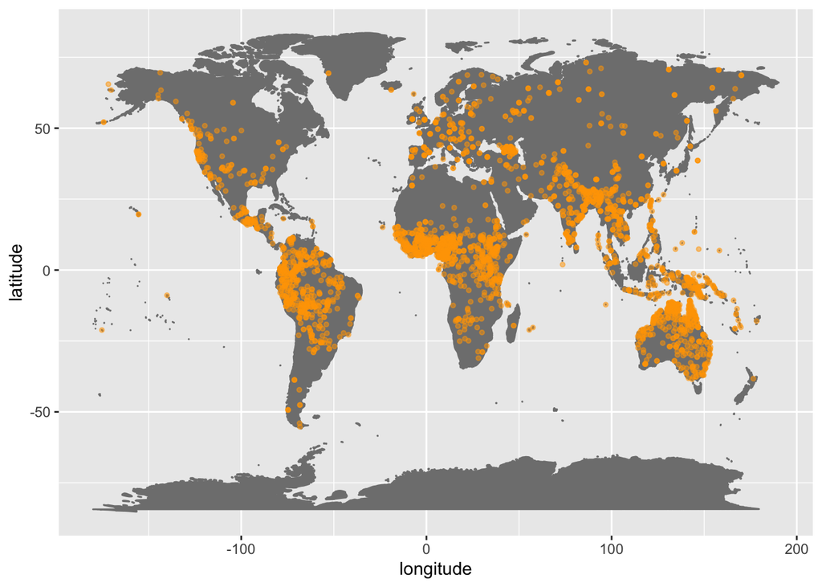

```r
ggplot(data=phoible_geo, aes(x=longitude, y=latitude)) +
    borders("world", colour="gray50", fill="gray50") +
    geom_point(alpha=0.5, size=1, colour="orange")
```

Of course this does not show all of the data points for languages that are *not* in PHOIBLE!

# Phonological features in PHOIBLE

In addition to phoneme inventories, PHOIBLE includes distinctive feature data for every phoneme in every inventory. The feature system was created by the PHOIBLE developers to be descriptively adequate cross-linguistically. In other words, if two phonemes differ in their graphemic representation, then they should necessarily differ in their featural representation as well (regardless of whether those two phonemes coexist in any known doculect). The feature system is loosely based on the feature system in Hayes (2009) with some additions drawn from Moisik & Esling (2011).

Note that the feature system is potentially subject to change as new languages are added in subsequent editions of PHOIBLE, and/or as errors are found and corrected. More information about the PHOIBLE feature set can be found [here](https://github.com/phoible/dev/tree/master/raw-data/FEATURES).

# How is PHOIBLE used in academic research and/or industry?

The data in PHOIBLE have been used in many published research papers pertaining to a variety of scientific fields and industrial applications. For a sampling, view Google Scholar’s list of [papers citing PHOIBLE](https://scholar.google.com/scholar?oi=bibs&hl=en&cites=576981116309388928&as_sdt=5).

# References

Chanard C (2006). Systèmes alphabétiques des langues africaines. Online: urlhttp://sumale.vjf.cnrs.fr/phono/.

Chao YR (1934). The non-uniqueness of phonemic solutions of phonetic systems. *Bulletin of the Institute of History and Philology, Academia Sinica*, *4*(4).

Crothers JH, Lorentz JP, Sherman DA, & Vihman MM (1979). *Handbook of phonological data from a sample of the world’s languages: A report of the Stanford Phonology Archive*. Palo Alto, CA:

Cysouw M, & Good J (2013). Languoid, Doculect, and Glossonym: Formalizing the notion “language”. *Language Documentation & Conservation*, *7*, 331–360. http://hdl.handle.net/10125/4606

Hartell RL, Ed (1993). *Alphabets des langues africaines*. UNESCO and Société Internationale de Linguistique.

Hayes B (2009). *Introductory phonology*. Blackwell.

Hockett CF (1963). The problem of universals in language. In J. H. Greenberg (Ed.), *Universals of language* (Vol. 2, pp. 1–29). Cambridge, MA: MIT Press.

Hyman LM (2008). Universals in phonology. *The Linguistic Review*, *25*(1-2), 83–137. doi:10.1515/TLIR.2008.003

Maddieson I (1984). *Patterns of sounds*. Cambridge Studies in Speech Science and Communication. New York: Cambridge University Press. http://ebooks.cambridge.org/ref/id/CBO9780511753459

Maddieson I, & Precoda K (1990). Updating UPSID. *UCLA Working Papers in Phonetics*, *74*, 104–111. http://escholarship.org/uc/item/71s1701m

Michael L, Stark T, & Chang W (2012). South American phonological inventory database. University of California. http://linguistics.berkeley.edu/saphon/en/

Moisik SR, & Esling JH (2011). The “whole larynx” approach to laryngeal features. In *Proceedings of the 17th International Congress of Phonetic Sciences* (pp. 1406–1409). Hong Kong.

Moran S (2012). *Phonetics information base and lexicon* (Doctoral Dissertation). University of Washington, Seattle, WA. http://hdl.handle.net/1773/22452

Nikolaev D, Nikulin A, & Kukhto A (2015). The database of Eurasian phonological inventories. http://eurasianphonology.info/

Ramaswami N (1999). *Common linguistic features in Indian languages: Phonetics*. Central Institute of Indian Languages.

Round E (2019). Australian phonemic inventories contributed to PHOIBLE 2.0: Essential explanatory notes (version 1.0). http://doi.org/10.5281/zenodo.3464333

Terrill A (1998). *Biri*. Languages of the world. Materials. München: LINCOM Europa. https://nla.gov.au/nla.cat-vn573959